# Stepwise Forward Regression

Fabrice Mettler

2025-05-26

## General informations

In this report exercise I will perform a stepwise forward regression for the task of modelling the GPP (GPP_NT_VUT_REF) as a function of predictors available in the data set. The data set contains air temperature (TA_F), incoming short-wave radiation (SW_IN_F), incoming long-wave radiation (LW_IN_F), vapor pressure deficit (VPD_F), atmospheric pressure (PA), precipitation (P), wind speed (WS), incoming photosynthetic photon flux density (PPFD_IN), CO2 (CO2_F_MDS) and friction velocity (USTAR).

## Evaluation of the bivariate models

For that, I start with bivariate models to evaluate which single predictor fits best.

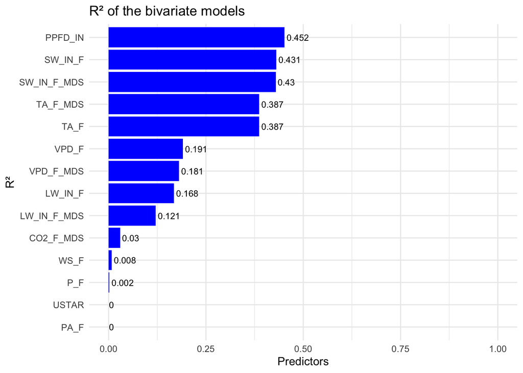

```r
predictors <- data_stepwise |> # defining the predictors
  select(- siteid, -TIMESTAMP, - GPP_NT_VUT_REF) |>
  names()

bivariate_regressions <- predictors |> # creating a linear regression for each predictor
  set_names() |>
  map(~ lm(as.formula(paste("GPP_NT_VUT_REF", "~", .x)), data = data_stepwise))

bivariate_regressions |>
  map_dbl(~ summary(.x)$r.squared) |>
  enframe(name = "predictor", value = "r_squared") |>
  mutate(r_squared = round(r_squared, 3)) |>
  ggplot2::ggplot(aes(x = reorder(predictor, r_squared), y = r_squared)) +
  geom_col(fill = "blue") +
  geom_text(aes(label = r_squared), hjust = -0.1, size = 3) +
  coord_flip() +
  labs(
    title = "R² of the bivariate models",
    x = "R²",
    y = "Predictors") +
  theme_minimal() +
  ylim(0, 1)
```

The highest correlation is observed with the predictor PPFD_IN (R² = 0.452) which is expected since plants use photon energy for photosynthesis. When more photons are available, plants assimilate more CO2. We can also see that predictors which were gap filled with MDS (end with _MDS) have a very similar R² to the same predictor without gap filling, which is also very intuitive. The friction velocity and the atmospheric pressure show no correlation. Precipitation has a very low correlation with the GPP, which is explainable as precipitation usually comes with high cloud cover and therefore low sun light which reduces photosynthesis.

## Stepwise forward regression

```r
source("../R/stepwise_forward.R")
model_1 <- stepwise_forward(data = data_stepwise, response = "GPP_NT_VUT_REF", predictors = predictors)

lm_result <- tail(model_1$final_model, 1)[[1]]
summary(lm_result)
```

```
##
## Call:
## lm(formula = formula_p, data = data)
##
## Residuals:
##     Min      1Q  Median      3Q     Max
## -7.7477 -1.2228 -0.1153  1.1085 12.3241
##
## Coefficients:
##               Estimate Std. Error t value Pr(>|t|)
## (Intercept) -1.5891656  0.4463032  -3.561 0.000371 ***
## PPFD_IN      0.0067222  0.0005163  13.021  < 2e-16 ***
## LW_IN_F      0.0152432  0.0006854  22.240  < 2e-16 ***
## VPD_F       -0.3885851  0.0077764 -49.970  < 2e-16 ***
## TA_F_MDS     0.1035322  0.0049296  21.002  < 2e-16 ***
## SW_IN_F      0.0127810  0.0010750  11.889  < 2e-16 ***
## P_F         -0.0233915  0.0026829  -8.719  < 2e-16 ***
## WS_F        -0.1374643  0.0138279  -9.941  < 2e-16 ***
## CO2_F_MDS   -0.0064341  0.0007675  -8.383  < 2e-16 ***
## PA_F         0.0077160  0.0032004   2.411 0.015922 *
## ---
## Signif. codes:  0 '***' 0.001 '**' 0.01 '*' 0.05 '.' 0.1 ' ' 1
##
## Residual standard error: 2.064 on 16864 degrees of freedom
##   (6137 observations deleted due to missingness)
## Multiple R-squared:  0.5982, Adjusted R-squared:  0.598
## F-statistic:  2790 on 9 and 16864 DF,  p-value: < 2.2e-16
```

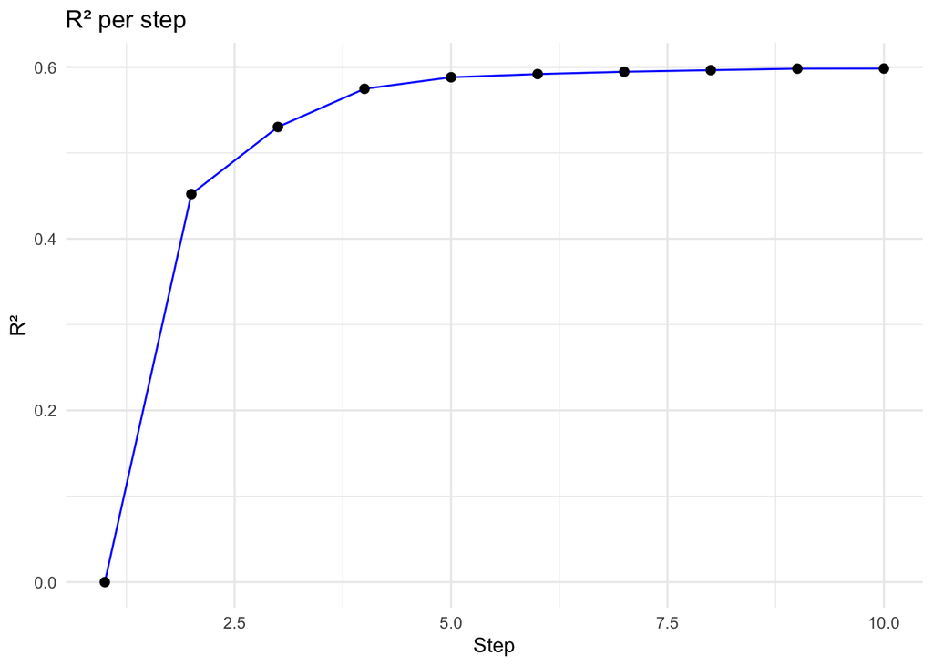

```r
rsq_vals <- map_dbl(model_1$final_model, ~ summary(.x)$r.squared)

rsq_plot <- tibble(
  Step = seq_along(rsq_vals),
  R_squared = rsq_vals
) |>
  ggplot(aes(x = Step, y = R_squared)) +
  geom_line(color = "blue") +
  geom_point(color = "black", size = 2) +
  labs(title = "R² per step",
       x = "Step",
       y = "R²") +
  theme_minimal()

rsq_plot
```

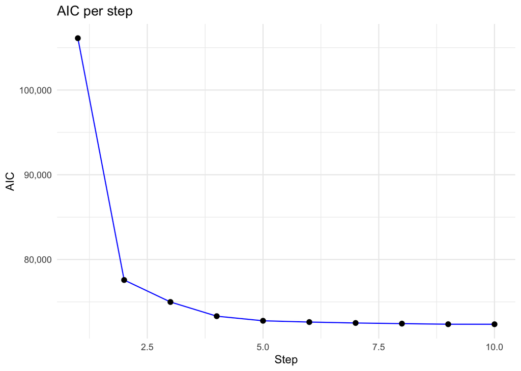

```r
aic_vals <- map_dbl(model_1$final_model, AIC)

aic_plot <- tibble(
  Step = seq_along(aic_vals),
  AIC = aic_vals
) |>
  ggplot(aes(x = Step, y = aic_vals)) +
  geom_line(color = "blue") +
  geom_point(color = "black", size = 2) +
  labs(title = "AIC per step",
       x = "Step",
       y = "AIC") +
  theme_minimal() +
  scale_y_continuous(labels = label_comma())

aic_plot
```

### Discussion of the results

In the figures above we see the improvement of the R² over the single steps of the step-wise forward regression. R² improves with a saturation curve, which means that the first 4 predictors contribute much to the model improvement while the rest of the predictors only lead to slight improvement. In the second plot, the AIC is presented over the single steps of the step-wise regression. Similar to the R², the AIC improves a lot until the first 4 steps when the improvement continues on a low level. From the result of the model, we see that out of the 14 possible predictors, the final model includes 9 of them. We also see that for predictors where gap-filled data was available, only one was used (either the gad-filled data or the non-gap-filled data). It is easy to imagine that the second predictor did not further improve the model, as most of the information was already included in the first one. Finally, i was wondering if it makes sense to accept a new predictor although it lead only to a very small improvement. It might be more appropriate to define a certain threshold, which a new predictor has to overcome in order to be included into the model. However, I assume this decision ultimately depends on the specific modeling context and objectives (e.g., model simplicity vs. predictive accuracy).